# Group Formation & Topic Selection

PS50008A Week 16 Lab Activity

Author

Gordon Wright

Published

26 February 2026

## What This Lab Is About

This isn’t a gruelling lab — but it’s an important one. By the end of this lab you need to have done three things:

**ImportantToday’s Three Goals**

1. **Form your group** (3–4 is ideal, but more or fewer is fine — the key thing is that you join a group)
2. **Choose your project topic** (from the example list, or propose your own)
3. **Find a key paper** — something to anchor your methodology, procedure, or hypothesis to

That’s it. Get those three things done and you’re set up for the rest of the term.

## The Road Ahead

Before we dive in, here’s where everything sits between now and the end of term.

### Your Four Assessments

| Assessment | Weight | Deadline |
| --- | --- | --- |
| **Research Plan** | 20% | Fri 27 Feb 2026, 12 noon |
| **MCQ Exam** | 20% | Wed 11 Mar (~1 hour, in lecture) |
| **EDS Assignment** | 20% | Fri 20 Mar, 12 noon (~1 hour) |
| **Research Report** | 40% | 1 May, 12 noon |

### Your Group Project Milestones

| Week | Lab Focus | Milestone |
| --- | --- | --- |
| **16 (now)** | Group formation, topic selection | Group registration |
| **17** | Finalising methodology | Methodology agreed |
| **18** | Finalising procedure, piloting with Gordon | Procedure complete |
| **19** | Data collection | Data collected |
| **20** | Write-up support | Report drafting begins |

### Quick Check

**1. Which assessment is due this Friday?**

**2. Which assessment is worth the most?**

**3. When does your group need to collect data?**

## Part 1: Form Your Group

### Why This Matters

Your group will work together for the rest of the term — choosing a topic, designing a study, collecting data, and sharing results. Each person then writes their own individual Research Report (2,000 words, due 1 May).

**Group size:** 3–4 students is ideal, but larger or smaller groups are fine. The most important thing is that **everyone joins a group**.

**WarningGroup Allocation**

Students not part of a registered group this week will be **allocated to a group** if they emerge down the line. So please register during this lab — even if your plans are still forming.

### Register Your Group

Once you’ve found your people, **register your group using this form**:

**ImportantGroup Registration Form**

**[Register your group here](https://forms.office.com/Pages/ResponsePage.aspx?id=Px9DDcEgHEaVikaynU4CG8gqdkQ5QElOkXjIDHSz7DVURjBMUUo1TFNBUElCUEpGWVlZRzFSMDdYVy4u)**

Enter your group members’ names and any preliminary topic ideas. You can change your topic later — the important thing is to register.

### Group Setup Checklist

**NoteDo These Now**

- Exchange contact details (email, phone, WhatsApp)
- Set up a group chat
- Agree on how you’re going to work together
- Familiarise yourself with the weekly milestones (see table above)

### Together vs. Individually

**Together (Weeks 16–20):** Choose topic, find papers, design the study, create materials, collect data, review results.

**Individually (after term):** Write your own 2,000-word Research Report using the group’s shared data. Same data, different reports. **Do NOT share written drafts** — that’s academic misconduct.

**1. The Research Report is:**

**2. You should share with your group members:**

**3. If two group members submit very similar reports, this is:**

## Part 2: Choose Your Topic

### What Makes a Good Topic?

Your project needs to be:

- **Testable with a t-test** — either a between-groups comparison (independent samples) or a within-subjects comparison (repeated measures) across two conditions
- **Feasible in scale** — your group of 3–4 should be able to run ~15–20 participants in a couple of hours. Think short tasks: memorise 20 words, 2-minute distractor, 2-minute recall — that sort of size
- **Ethically straightforward** — no deception that could cause distress, no sensitive topics, nothing requiring specialist equipment

### Option 1: Choose from the Example List

I’ve put together **9 fully scoped project options**, all ready to go. You’re welcome to pick one directly.

**[View the Project Options](https://littlemonkeylab.github.io/PS50008A_2526/project/group-project-options.html)**

Here’s a quick comparison:

| Project | Topic | Domain | Expected Effect | Materials |
| --- | --- | --- | --- | --- |
| A | Smiling & approachability | Social | Medium–large | Low (photos + paper) |
| B | Background music & recall | Cognitive | Medium | Low (speaker + phone) |
| C | Colour & memory | Cognitive | Small–medium | Low (colour printer) |
| D | Imagery vs repetition | Cognitive | Medium–large | Very low (paper only) |
| E | Phone presence & attention | Social/Cognitive | Small–medium | Very low (own phones) |
| F | Testing effect on learning | Cognitive | Medium–large | Low (paper only) |
| G | Social facilitation | Social | Small–medium | Low (confederates) |
| H | Anchoring & estimates | Social/Cognitive | Large | Very low (paper only) |
| I | Name stereotypes & competence | Social | Small–medium | Very low (paper only) |

### Option 2: Propose Your Own

If none of the examples appeal, you can propose your own topic. You’ll need to:

1. **Identify a clear IV with two levels** (e.g., music vs silence, phone visible vs hidden)
2. **Identify a measurable DV** (e.g., number of words recalled, response time, rating score)
3. **Find at least one paper** to anchor your hypothesis and methodology to
4. **Check it’s ethically straightforward** — if in doubt, ask Gordon

**4. A good project topic for this module must be testable with:**

**5. In a between-subjects design:**

**6. In a within-subjects design:**

## Part 3: Find a Key Paper

### Why You Need One

Every project needs a foundation — a paper that gives you:

- A **concept or theory** to base your hypothesis on
- An **operationalisation** you can adapt (how did they measure the DV? What stimuli did they use?)
- A **procedure** you can build from or simplify

A single well-chosen paper is more valuable than three vaguely related ones.

### Where to Look

**Starting-point papers** are available on Learn for each of the 9 example topics:

- **[Project papers folder on Learn](https://learn.gold.ac.uk/mod/folder/view.php?id=1795121)** — a couple of papers per topic. They’re not all perfect, but they offer a starting point for operationalisation, background, or methodology.

These may not be the ideal paper for your specific angle — a quick literature search may turn up something better:

**TipQuick Search Tips**

- **PsycINFO** (via [Goldsmiths Library](https://www.gold.ac.uk/library/)) — psychology-specific, peer-reviewed
- **Google Scholar** (scholar.google.com) — broader coverage, citation tracking
- Start with your key variables as search terms
- Use **quotation marks** for exact phrases (e.g., `"background music" AND recall`)

If your group has chosen its own topic (not from the list), finding a source paper is essential — it’s what your methodology and hypothesis will be built on.

**1. When you first find a paper, you should read:**

**2. The Method section of a relevant paper helps you because:**

True or False: A paper published in 2010 can still be a useful source if it’s highly cited and relevant.

True or False: Wikipedia is an acceptable source for your Research Report reference list.

## Project Resources

All the documents and templates you need are in one place:

| Resource | What it is |
| --- | --- |
| **[Project Options](https://littlemonkeylab.github.io/PS50008A_2526/project/group-project-options.html)** | 9 example topics, fully scoped |
| **[Project Toolkit](https://littlemonkeylab.github.io/PS50008A_2526/project/project-toolkit.html)** | Overview of each project with more detail |
| **[Papers Folder (Learn)](https://learn.gold.ac.uk/mod/folder/view.php?id=1795121)** | Starting-point papers for each topic |
| **[Template Documents (Learn)](https://learn.gold.ac.uk/mod/folder/view.php?id=1795124)** | Templates you need to complete, with worked examples |
| **[Project Directory (Learn)](https://learn.gold.ac.uk/course/section.php?id=588322)** | Full project section on Learn |

**NoteOneDrive Group Folder**

Each group will be given a shared folder on OneDrive. All your project documents and materials must be submitted there as you go.

## What You’ll Get Back: Data Analysis I

After your group collects data, I’ll run the analysis and return a one-page summary like this — personalised to your group. The tabbed examples below show the **layout** you can expect (between-subjects, within-subjects / paired, and a second between-subjects style).

**TedImoBea (between-subjects)**

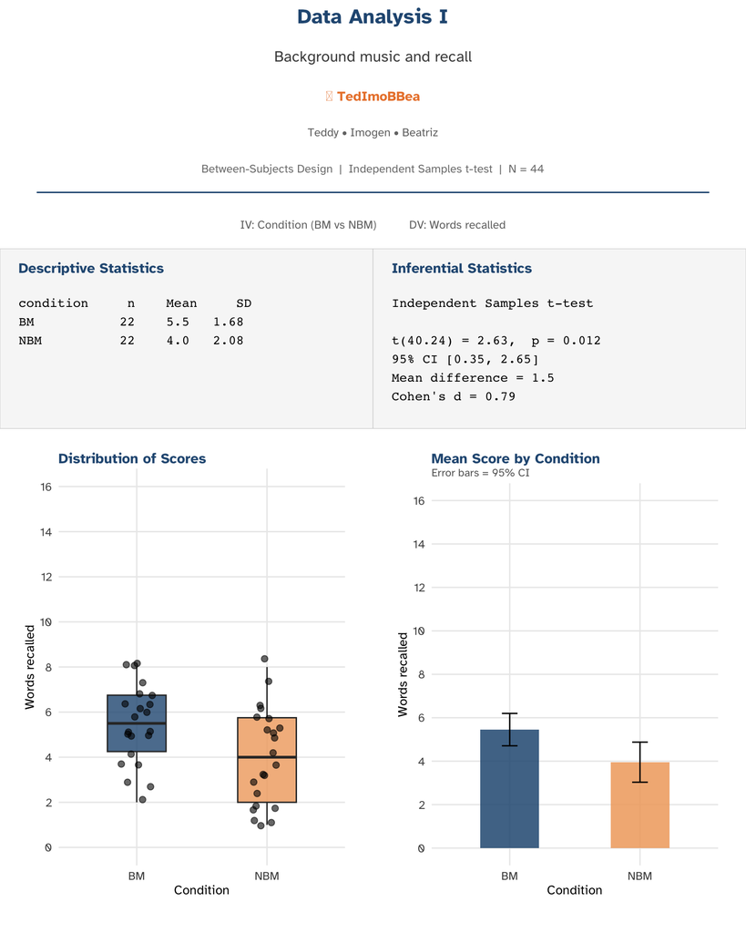

Data Analysis I return — TedImoBea

**JFKz Girlies (between-subjects)**

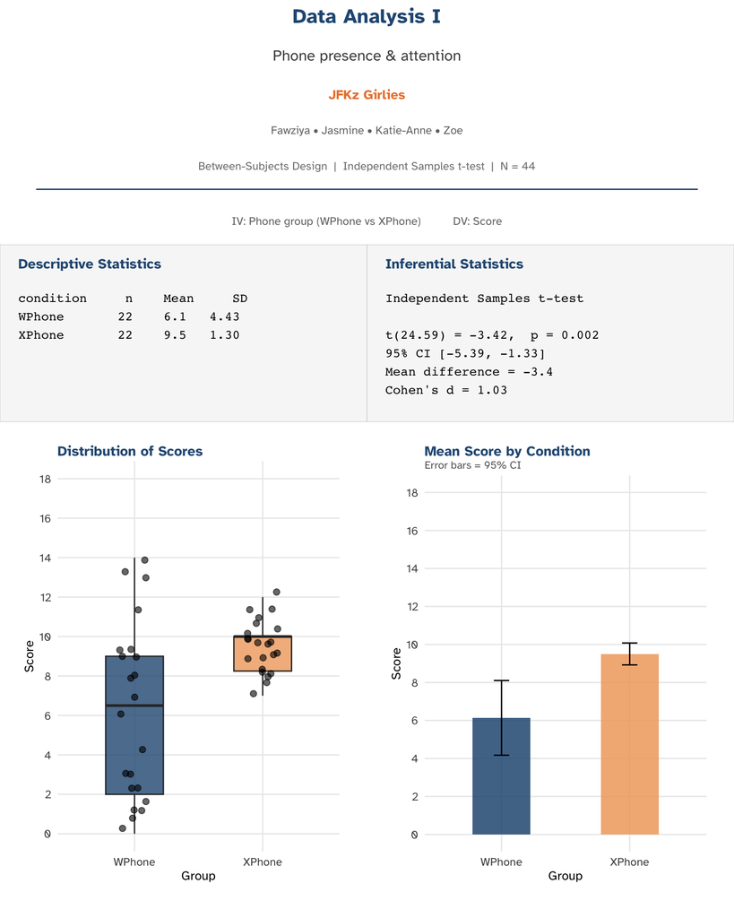

Data Analysis I return — JFKz Girlies

**DNM (within-subjects / paired)**

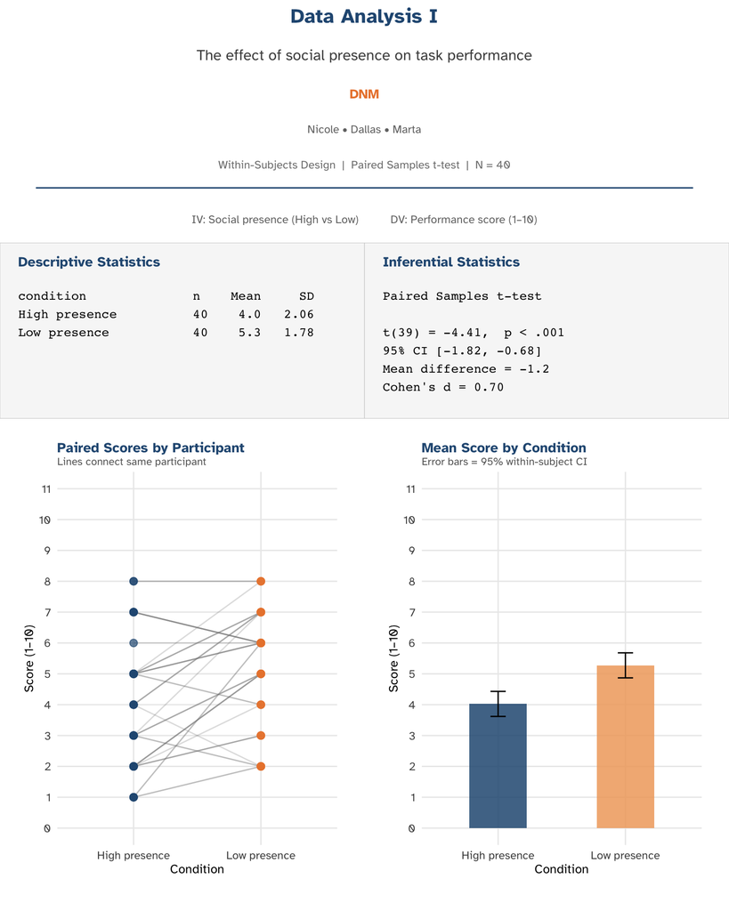

Data Analysis I return — DNM

**The Boyz (between-subjects — wide CSV: one column per group)**

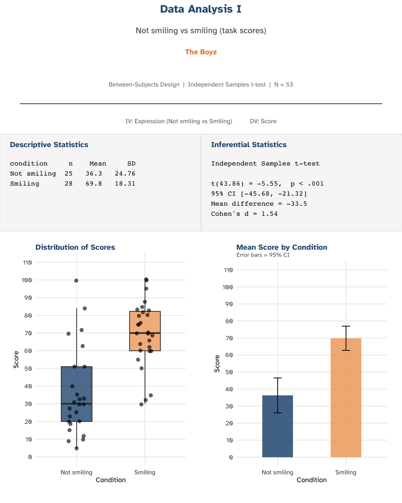

Data Analysis I return — The Boyz

**TipYou Don’t Run the Analysis**

I provide the statistical output — your job in the Research Report is to **interpret and discuss** these results, not to generate them.

## Before You Leave

**ImportantChecklist**

- Formed a group and **[registered it](https://forms.office.com/Pages/ResponsePage.aspx?id=Px9DDcEgHEaVikaynU4CG8gqdkQ5QElOkXjIDHSz7DVURjBMUUo1TFNBUElCUEpGWVlZRzFSMDdYVy4u)**
- Chosen your project topic (from the list or your own)
- Found or identified a key paper to anchor your project
- Exchanged contact details and set up a group chat
- Looked at the [template documents](https://learn.gold.ac.uk/mod/folder/view.php?id=1795124) on Learn

## Key Dates Reminder

| When | What |
| --- | --- |
| **Tomorrow** Fri 27 Feb, 12 noon | Research Plan due via Learn |
| **Week 17** Thu 5 Mar | Group: finalise methodology |
| **Week 18** Wed 11 Mar | **MCQ Exam** (~1 hour, in lecture) |
| **Week 18** Thu 12 Mar | Group: finalise procedure, pilot with Gordon |
| **Week 19** Fri 20 Mar, 12 noon | **EDS Assignment** due (~1 hour) |
| **Week 19** Thu 19 Mar | Group: **collect data** |
| **Week 20** Thu 26 Mar | Write-up support |
| **1 May**, 12 noon | **Research Report** due |

## Next Steps

1. **Tomorrow (Friday):** Submit your **Research Plan** by **12 noon** via Learn
2. **Next week onwards:** Work collaboratively with your group to hit each week’s milestone — see the [project toolkit](https://littlemonkeylab.github.io/PS50008A_2526/project/project-toolkit.html) for guidance
3. If you have questions before Thursday, Gordon is available — or post in the module discussion forum